# Part_II_slide_deck slides

## Part II - ProsperLoanData Insights.

### by Iwuoha Joshua

## Investigation Overview

> The main focus will be on the loan status and original loan amount, where i will attempt to describe the factors that affect them and to what extent. What exactly is the main indicator on a customer's ability to repay a loan? I have answered this by looking at the relationship between the debt to income ratio and the loan status, and from the plot, discovered that the lower the debt to income ratio, the more likely a customer will repay their debt. The second question would be What essentially determines the amount of loan a customer has access to? And to understand this, i have looked at the relationship between the original loan amount and income range as well as the relationship between the original loan amount and prosperscore.

## Loan Status Distribution

> The majority of the customers are still repaying their debt, few have defaulted and quite a lot have paid back completely. As for the rest of the categories, there are very few observations.

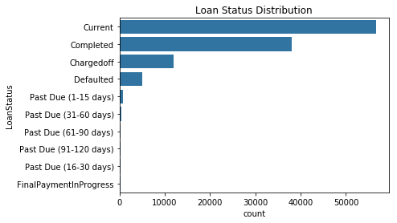

## Debt to Income Ratio Distribution.

> The chart is unimodal with a peak between 0.2 - 0.3. The histogram followed the expected pattern as there are fewer loans for the higher debt-to-income ratios, as we see the drop in the chart from 0.4. A lower debt-to-income ratio means a stroger ability to payback the loan amount, and we can see that more customers with a strong income base in proprtion to the loan amount taken were given the loan.

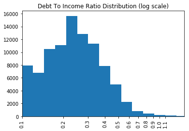

## Loan Status and Debt To Income Ratio Comparison.

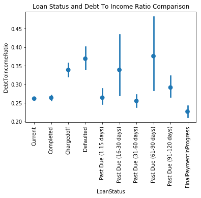

## Original Loan Amount Distribution.

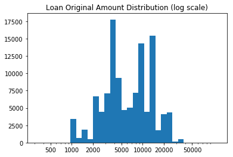

## Income Range Distribution.

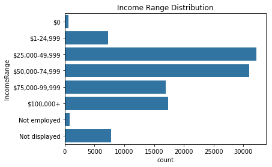

## Loan Original Amount vs Income Range.

> There is an inconsistency in the data as the mean loan amount for borrowers that declared a zero dollar income is surprisingly as high as 7000. Other than that, the pattern for the other categories follow the expected intuition that the mean loan amount would rise as the income bracket gets higher and fall for those that are not employed as they are less likely to repay the loan. Interesting to note is the fact that those who did not indicate their income range had access to a relatively low loan amount.

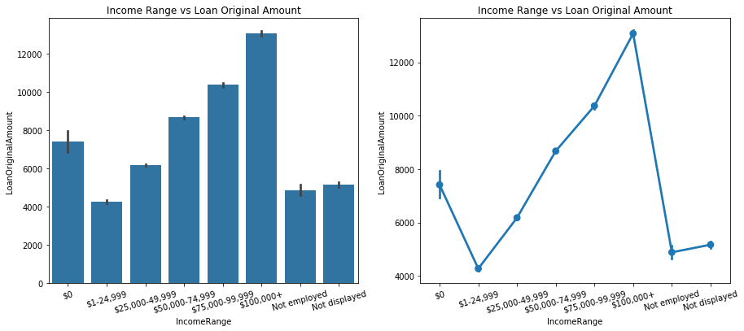